# Read_me

Galindo, B. A

2024-04-29

# Raw data

```r
data <- read.csv("/home/bambrozi/2_CORTISOL/Data/T4_Elora_Data_04_25_2024.csv")

# Replace "treated" with NA
data$T4Cortisol[data$T4Cortisol == "treated" | data$T4Cortisol == "Treated at T2" | data$T4Cortisol == "treated at T2"] <- NA
# Convert the column to numeric, coercing non-numeric values to NA
data$T4Cortisol <- as.numeric(as.character(data$T4Cortisol))
#Filtering only the lines with values
data <- data[!is.na(data$T4Cortisol),]
#creating new data file cleaned
write.csv(data, "/home/bambrozi/2_CORTISOL/Data/data_clean.csv", row.names = F)

print(data)
```

# Continuous Phenotype

```r
# Summary Statistics
summary(data$T4Cortisol)
# Histogram
hist(data$T4Cortisol, breaks = 20, main = "Histogram of T4 Cortisol", xlab = "T4 Cortisol")
# Boxplot
boxplot(data$T4Cortisol, main = "Boxplot of T4 Cortisol", ylab = "T4 Cortisol")
# Density Plot
plot(density(data$T4Cortisol), main = "Density Plot of T4 Cortisol", xlab = "T4 Cortisol", ylab = "Density")
# Calculate the theoretical quantiles
qqnorm(data$T4Cortisol, main = "QQ Plot of T4Cortisol", xlim = c(min(qqnorm(data$T4Cortisol)$x), max(qqnorm(data$T4Cortisol)$x)), ylim = c(min(qqnorm(data$T4Cortisol)$y), max(qqnorm(data$T4Cortisol)$y) + 2 * IQR(qqnorm(data$T4Cortisol)$y)))
# Add the QQ line
qqline(data$T4Cortisol, col = "red")
```

**Summary statistics**

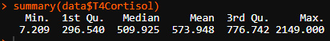

**Histogram**

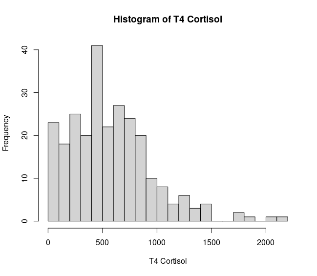

**Density**

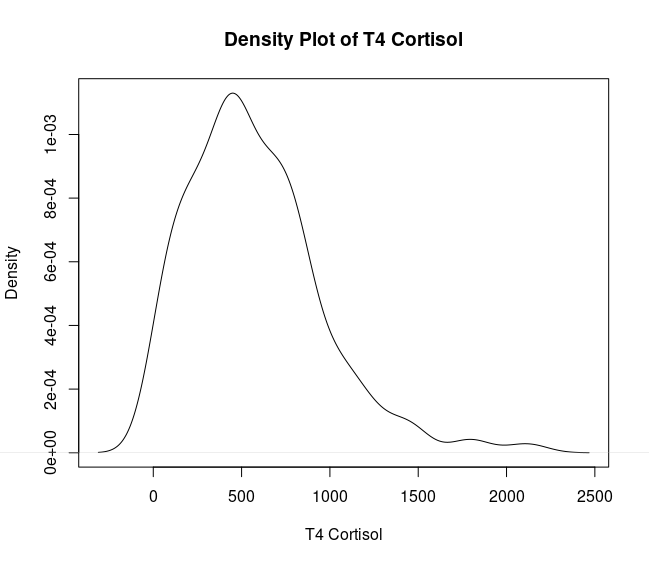

**Box_Plot**

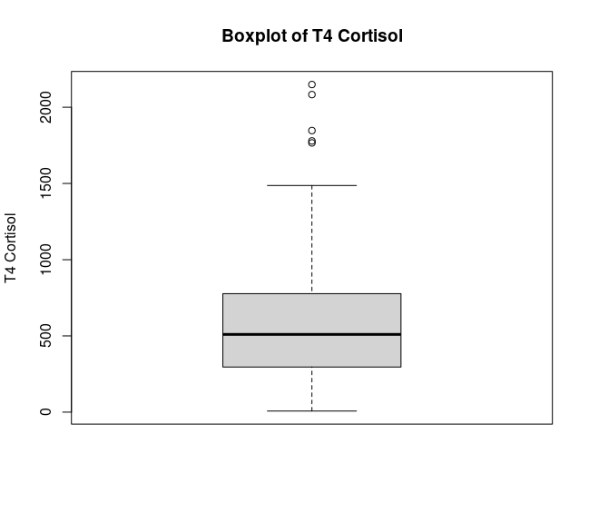

**qq_Plot**

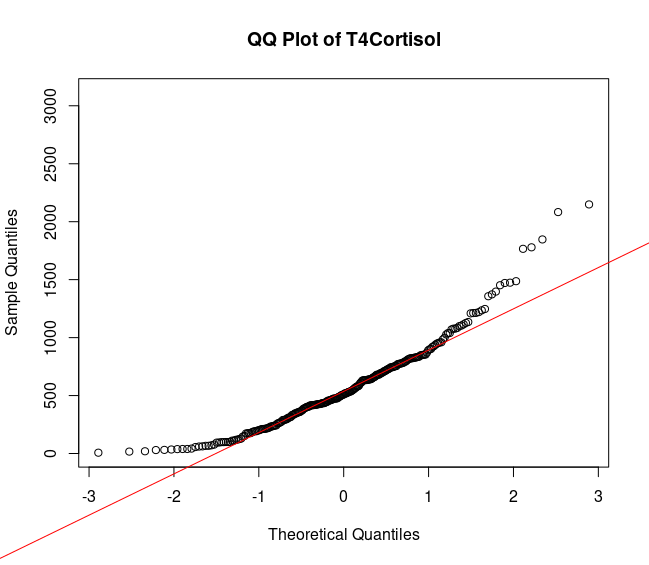

[figure not shown]

## Categorical Phenotype

I received from Umesh a e-mail informing the three categories that the animals could be sorted based on their cortisol concentration.

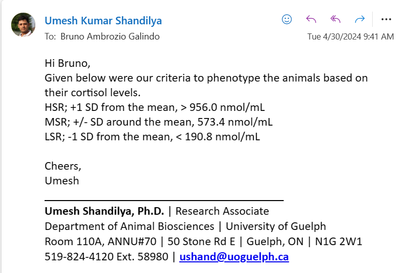

```r
data$Categorical <- ifelse(data$T4Cortisol >= 956, "H",
                           ifelse(data$T4Cortisol <= 190.8, "L", "M"))

table(data$Categorical)
library(ggplot2)

# Reorder the levels of the 'Categorical' column
data$Categorical <- factor(data$Categorical, levels = c("L", "M", "H"))

# Create the histogram with reordered categories
ggplot(data, aes(x = Categorical, fill = Categorical)) +
  geom_bar() +
  labs(title = "Histogram of T4Cortisol by Category",
       x = "Category",
       y = "Frequency") +
  theme_minimal()

# Create the histogram
ggplot(data, aes(x = T4Cortisol, fill = Categorical)) +
  geom_histogram(binwidth = 50, color = "black", alpha = 0.7) + # Adjust binwidth as needed
  labs(title = "Histogram of T4Cortisol with Color by Category",
       x = "T4 Cortisol",
       y = "Frequency",
       fill = "Category") +
  scale_fill_manual(values = c("H" = "red", "M" = "blue", "L" = "green")) + # Adjust colors if needed
  theme_minimal()

# Create the density plot
ggplot(data, aes(x = T4Cortisol, fill = Categorical)) +
  geom_density(alpha = 0.3) +
  labs(title = "Density Plot of T4Cortisol with Color by Category",
       x = "T4Cortisol",
       y = "Density",
       fill = "Category") +
  scale_fill_manual(values = c("H" = "red", "M" = "blue", "L" = "green")) + # Adjust colors if needed
  theme_minimal()

# Create a density plot
ggplot(data, aes(x = T4Cortisol)) +
  geom_density() +
  geom_vline(xintercept = c(956, 190.8), linetype = "dashed", color = "red") +
  labs(title = "Density Plot of T4Cortisol with Vertical Lines",
       x = "T4Cortisol",
       y = "Density") +
  theme_minimal()
```

The animals were sorted in these three categories >H = Hight >M = Medium >L = Low

The individuals frequency distribution in theese categories are shown in the plots below

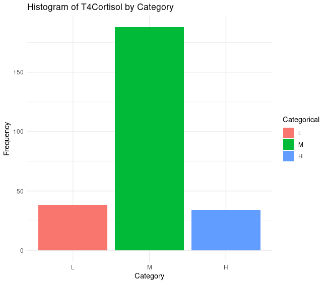

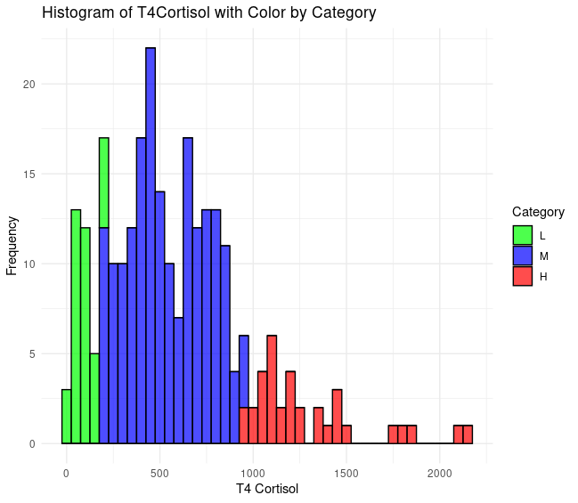

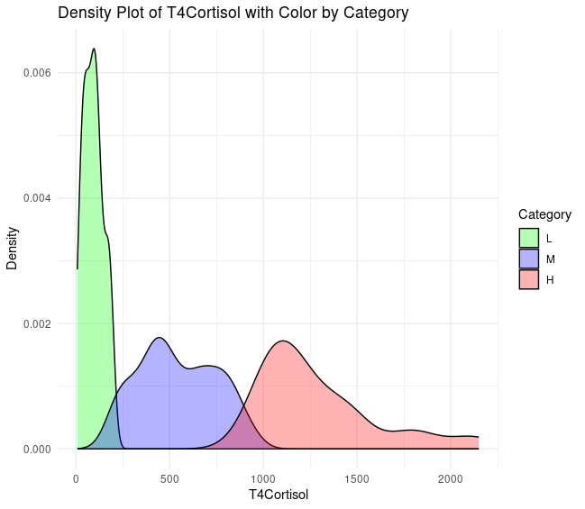

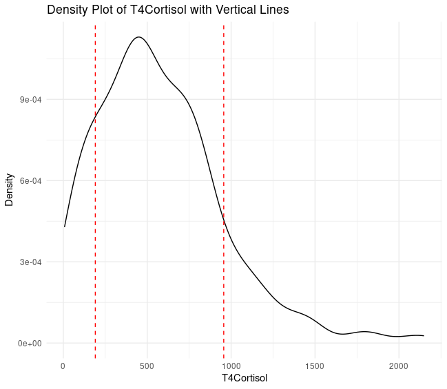

## Removing “outliers”

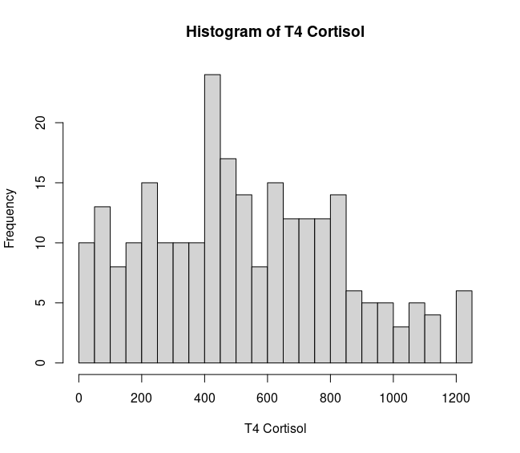

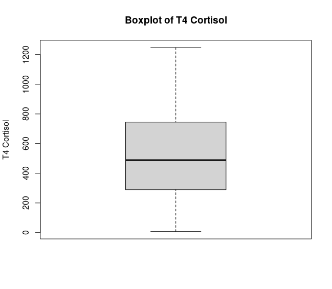

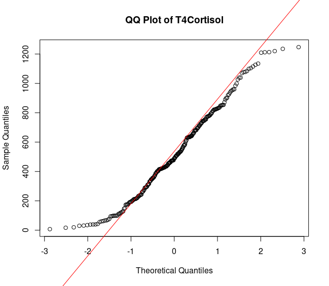

```r
library(tidyverse)

data_no_out <- filter(data, T4Cortisol < 1250)

# Create QQ plot
qqnorm(data_no_out$T4Cortisol, main = "QQ Plot of T4Cortisol", xlab = "Theoretical Quantiles", ylab = "Sample Quantiles")
qqline(data$T4Cortisol, col = "red")

boxplot(data_no_out$T4Cortisol, main = "Boxplot of T4 Cortisol", ylab = "T4 Cortisol")

hist(data_no_out$T4Cortisol, breaks = 20, main = "Histogram of T4 Cortisol", xlab = "T4 Cortisol")

shapiro.test(data$T4Cortisol)
```

# GENOTYPES

Lucas Alcântara sent me the path to the genotype and pedigree files: /data/cgil/daiclu/6_Data/database/public_output/bruno

[figure not shown]

In this folder we found the following files:

- **bruno_gntps.txt**: the file with the genotypes in **012 format**
- **bruno_ids.csv**: file with elora_id, cdn_id, iid
- **bruno_ped.id.csv**: pedigree with cdn_id
- **bruno_ped.iid.csv**: pedigree with iid

I made a copy of this files in a folder called **Raw_files**:

/home/bambrozi/2_CORTISOL/RawFiles

This directory has two sub-directories:

- Genotypes
- Pedigree

## Transforming the Genotypes in 012 format to plink format

To perfome this I used two codes

1. Add “column names”

```bash
sed -i '1i id Call' genotypes.txt
```

2. Recode in python

```python
filename = 'bruno_gntps.txt'

outputFileOpen = open('genoplink.ped','w')


recode = {'0':['C','C'] , '1':['A','C'] , '2':['A','A'] , '5':['0','0'] }
for line in open(filename,'r'):
    if 'Call' in line : continue

    ids, call = line.strip().split()
    genotypes = [ recode[geno012][0] +' '+ recode[geno012][1] for geno012 in call ]

    outputFileOpen.write("%s %s %s %s %s %s %s\n" % ('HO', ids, '0','0','0','-9',' '.join(genotypes)) )
```

Now I have a folder called **/home/bambrozi/2_CORTISOL/Geno_files** with the file named **genoplink.ped**

# GWAS

## Checking with Phenotyped Animals also have Genotype

```r
library(data.table)

pheno <- read.csv("/home/bambrozi/2_CORTISOL/Data/data_clean.csv")
ped <- read.csv("/home/bambrozi/2_CORTISOL/RawFiles/Pedigree/bruno_ids.csv")
geno <- fread("/home/bambrozi/2_CORTISOL/Geno_files/genoplink.ped")
geno <- geno[,c("V2")]

#Bringing cdn_id to my phenotype file
#Generate a index with the match
matching_indices <- match(pheno$ID, ped$elora_id)
# Then, assign 'cdn_id' from 'ped' to 'pheno' where there are matches
pheno$cdn_id <- ifelse(!is.na(matching_indices), ped$cdn_id[matching_indices], NA)

#Making a phenotype file only with genotyped animals
pheno_genotyped <- pheno[pheno$cdn_id %in% geno$V2,]

#check if all animals in this file are genotyped
checkk <- pheno_genotyped$cdn_id %in% geno$V2
sum(checkk)
```

## Generating a Phenotype file

The phenotype file should have three columns: FID, Animal_id, Phenotype

```r
HO <- rep("HO", 252)

pheno_gwas <- as.data.frame(cbind(HO, pheno_genotyped$cdn_id, pheno_genotyped$T4Cortisol))

colnames(pheno_gwas) <- c("FID", "cdn_id", "cortisol")

pheno_gwas$cdn_id <-  as.numeric(pheno_gwas$cdn_id)
pheno_gwas$cortisol <- round(as.numeric(pheno_gwas$cortisol),2)

write.table(pheno_gwas, "/home/bambrozi/2_CORTISOL/GWAS/pheno_genotyped.txt", quote = F, row.names = F, col.names = T)
```

## Adjusting the SNP_map to .map

```r
map <- fread("/data/cgil/daiclu/6_Data/database/public_output/bruno/DGVsnpinfo.2404.ho")
morgan <- data.frame(X0 = rep(0, 45101))
mapa=as.data.frame(cbind(map$chr, map$snp_name, morgan$X0, map$location))
head(mapa)
write.table(x = mapa, file = "/home/bambrozi/2_CORTISOL/Geno_files/genoplink.map", row.names = FALSE, col.names = FALSE, sep = "\t", quote = FALSE)
```

## Generating the bfiles

```r
system("/home/local/bin/plink --cow --nonfounders --allow-no-sex --keep-allele-order --file /home/bambrozi/2_CORTISOL/Geno_files/genoplink --make-bed --out /home/bambrozi/2_CORTISOL/Geno_files/genoplink")
```

With the code above I generated the bfiles:

genoplink.bed

- genoplink.bim
- genoplink.fam
- genoplink.log
- genoplink.nosex

# Quality Control

We ran the code below to perfom the QC

```bash
#!/bin/bash

DATA=/home/bambrozi/2_CORTISOL/Geno_files/genoplink
RESULT=/home/bambrozi/2_CORTISOL/Geno_files_after_QC/genoplink_clean

/home/local/bin/plink \
    --bfile ${DATA} \
    --cow \
    --allow-no-sex \
    --hwe 1e-5 \
    --maf 0.01 \
    --geno 0.1 \
    --mind 0.1 \
    --keep-allele-order \
    --make-bed \
    --out ${RESULT}
```

The server screen outcome is shown below.

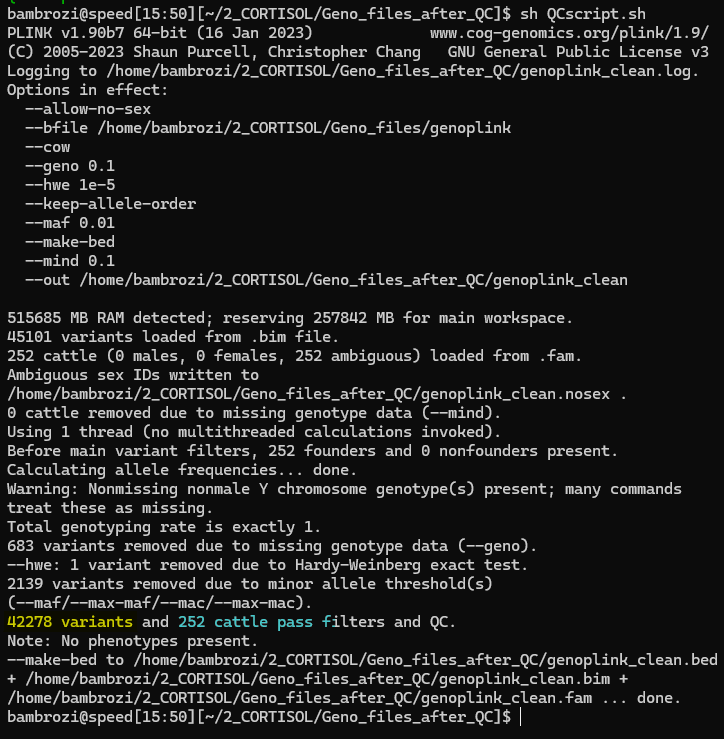

After the Quality Control we ended up with

- 252 samples
- 42,278 variants (SNPs)

# KING

To check for duplicated individuals I performed the KINSHIP analysis using one script from Larissa Braga. Running the King Analysis on Plink.

```bash
#!/bin/bash

DATA=/home/bambrozi/Extrm_ARS1_GrassHill_1/GENOTYPES/ONLY_GRASSHILL_AND_PHENO_after_QC/only_grasshill_and_pheno_clean
RESULT=/home/bambrozi/Extrm_ARS1_GrassHill_1/GENOTYPES/KING/result_king

plink2 \
    --bfile ${DATA} \
    --chr-set 29 \
    --make-king-table \
    --out ${RESULT}
```

This is the output screen on terminal:

[figure not shown]

The table below is the output /home/bambrozi/2_CORTISOL/Geno_files_after_KING/result_king.kin0 and have pairwise comparisons between all individuals.

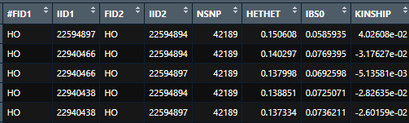

Now we should open in R and check for individuals with more than 0,354, to perform this we can use the code below, also provided by Larissa Braga:

```r
setwd("/home/bambrozi/2_CORTISOL/Geno_files_after_KING")

relatedness="result_king.kin0" ## change accordingly!!

library(data.table)

print(relatedness)
rel=fread(relatedness, h = T)
head(rel)

print("Individuals with different identifications above the cut off of 0.354:")
dup=subset(rel, KINSHIP >= 0.354  & IID1!=IID2)
print(dup)
nrow(dup)
```

So the code above will provide this output if there is any duplicated individual.

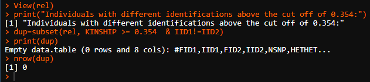

**We do not have any duplicated individual**

So the file to be used are those in the directory /home/bambrozi/2_CORTISOL/Geno_files_after_QC

> files:genoplink_clean

After Quality Control we didn’t lost any animal, so we don’t need to update our phenotype file

# PCA

```bash
#!/bin/bash

DATA=/home/bambrozi/Extrm_ARS1_GrassHill_1/PCA/imput_pca
RESULT=/home/bambrozi/Extrm_ARS1_GrassHill_1/PCA/pca_result

plink \
    --bfile ${DATA} \
    --keep-allele-order \
    --chr-set 29 \
    --pca \
    --out ${RESULT}
```

The PCA output:

[figure not shown]

### PCA Plot

After generate the Eigenvalues and Eigenvectors I used the code below to generate the PCA Plot

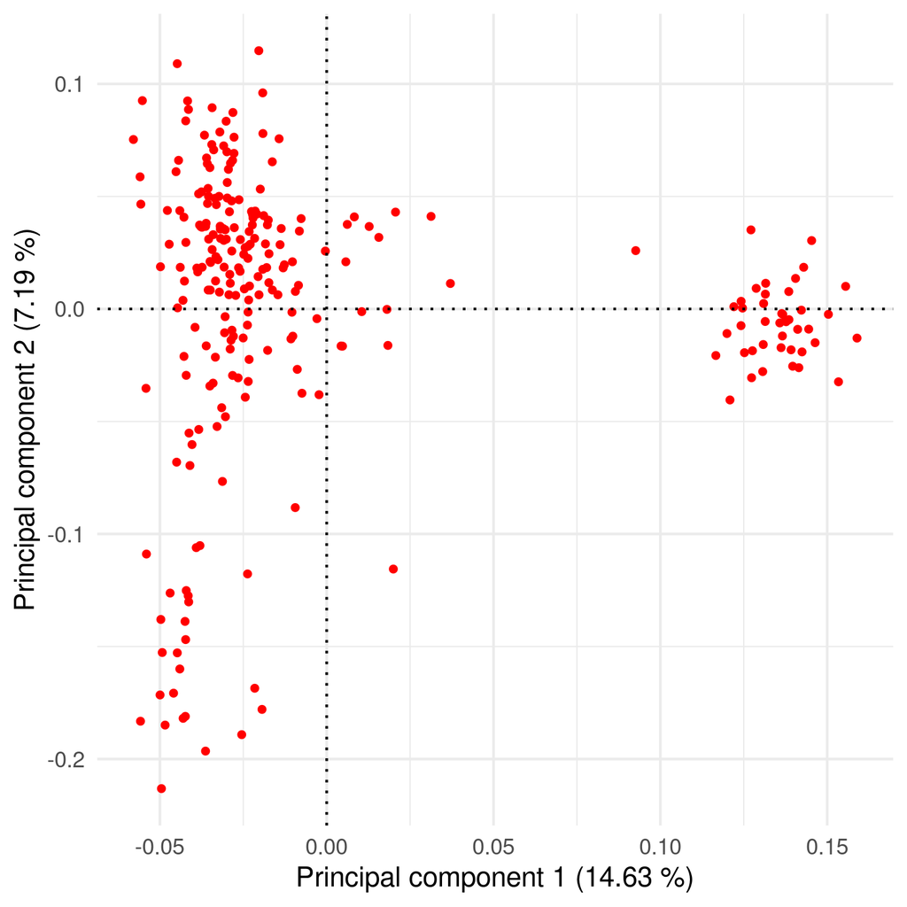

```r
setwd("/home/bambrozi/2_CORTISOL/PCA")

library(ggplot2)
library(tidyverse)

##
# Visualize PCA results
###

# read in result files
eigenValues <- read_delim("pca_result.eigenval", delim = " ", col_names = F)
eigenVectors <- read_delim("pca_result.eigenvec", delim = " ", col_names = F)

## Proportion of variation captured by each vector
eigen_percent <- round((eigenValues / (sum(eigenValues))*100), 2)


# PCA plot
png("pca-plink.eng.png", width=5, height=5, units="in", res=300)
ggplot(data = eigenVectors) +
  geom_point(mapping = aes(x = X3, y = X4), color = "red", shape = 19, size = 1, alpha = 1) +
  geom_hline(yintercept = 0, linetype="dotted") +
  geom_vline(xintercept = 0, linetype="dotted") +
  labs(x = paste0("Principal component 1 (", eigen_percent[1,1], " %)"),
       y = paste0("Principal component 2 (", eigen_percent[2,1], " %)")) +
  theme_minimal()
dev.off()


# PCA plot with animal ids
png("pca-plink.eng.animals_id.png", width=50, height=50, units="in", res=300)
ggplot(data = eigenVectors) +
  geom_point(mapping = aes(x = X3, y = X4), color = "red", shape = 19, size = 5, alpha = 1) +
  geom_text(mapping = aes(x = X3, y = X4, label = X2), size = 2, hjust = 0, vjust = 0) +  # Add labels for animal IDs
  geom_hline(yintercept = 0, linetype="dotted") +
  geom_vline(xintercept = 0, linetype="dotted") +
  labs(x = paste0("Principal component 1 (", eigen_percent[1,1], " %)"),
       y = paste0("Principal component 2 (", eigen_percent[2,1], " %)")) +
  theme_minimal()
dev.off()
```

# GWAS on GCTA

```bash
#!/bin/bash

DATA=/home/bambrozi/2_CORTISOL/Geno_files_after_QC/genoplink_clean
RESULT=/home/bambrozi/2_CORTISOL/GWAS/GWAS_result
PHENO=/home/bambrozi/2_CORTISOL/GWAS/pheno_genotyped.txt

/home/local/bin/gcta \
    --bfile ${DATA} \
    --mlma-loco \
    --pheno ${PHENO} \
    --autosome-num 29 \
    --autosome \
    --out ${RESULT}
```

This is te output from the code above:

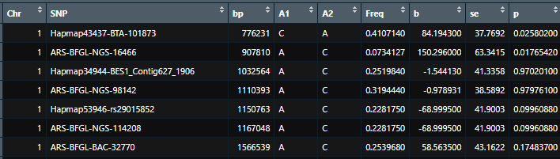

## Manhattan Plot - Bonferroni

```r
gwas<- read.table(file = "/home/bambrozi/2_CORTISOL/GWAS/GWAS_result.loco.mlma",
                  head=T, stringsAsFactors = F)
gwas$Chr<- as.factor(gwas$Chr)
gwas$logP<- -log10(gwas$p)
rmv<- which(gwas$logP == "NaN")
if (length(rmv) >=1) {gwas <- gwas[-rmv,]}
bonf<- -log10(0.05/nrow(gwas))

library(GHap)
ghap.manhattan(data=gwas,chr="Chr", bp="bp", y="logP", type="p", pch = 20,
               cex=1, lwd=1, ylab="", xlab="Chromossomes",
               main="GWAS Cortisol", backcolor="#F5EFE780", chr.ang=0,)
abline(h=(bonf), col="red2")
legend("topleft", col="red2", lwd=2, c("Bonferroni correction"), bty="n")
```

The code above creates a Manhattam Plot, the correction for multiple test is the Bonferroni correction

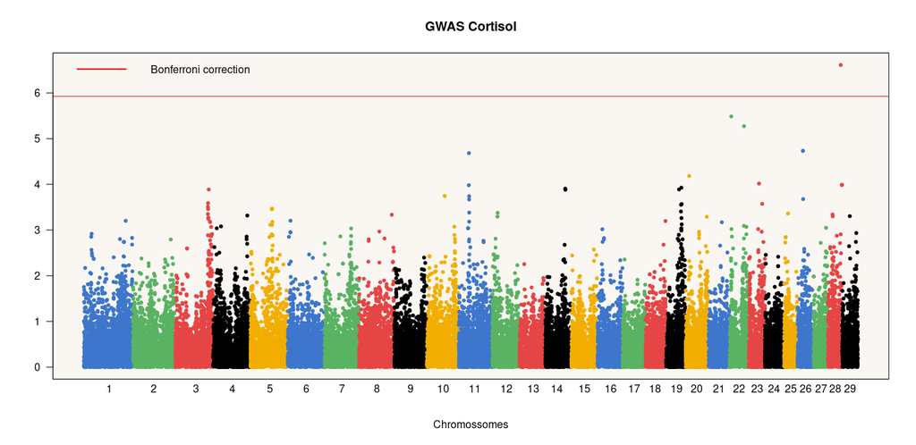

The code below will save information of Significant SNP.

```r
library(tidyverse)

SNP_sig_bonf <- filter(gwas, logP > bonf)
write.table(SNP_sig_bonf, file = "/home/bambrozi/2_CORTISOL/GWAS/SNP_sig_Bonf.txt",
            quote = FALSE, sep = "\t", row.names = FALSE, col.names = T)
```

Below we can see the 1 significant SNP for Bonferroni correction.

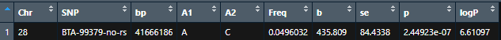

## FDR

```r
gwas$bh <- p.adjust(gwas$p, method = "BH") #FDR
```

The code below will create a file with the significant snp for FDR-BH

```r
SNP_sig_BH <- filter(gwas, bh < 0.05)
write.table(SNP_sig_BH, file = "/home/bambrozi/2_CORTISOL/GWAS/SNP_sig_BH.txt",
            quote = FALSE, sep = "\t", row.names = FALSE, col.names = T)
```

As outcome we can see that the FDR-BH method didn’t increase the number of significant SNP.

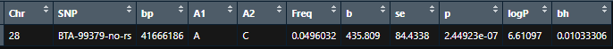

## Corrected Bonferroni for genome independent segments

Now we are going to apply a correction for multiple testing modifying the Bonferroni test adjusting not for the total number of SNPs but for the number of the independent segments in the genome.

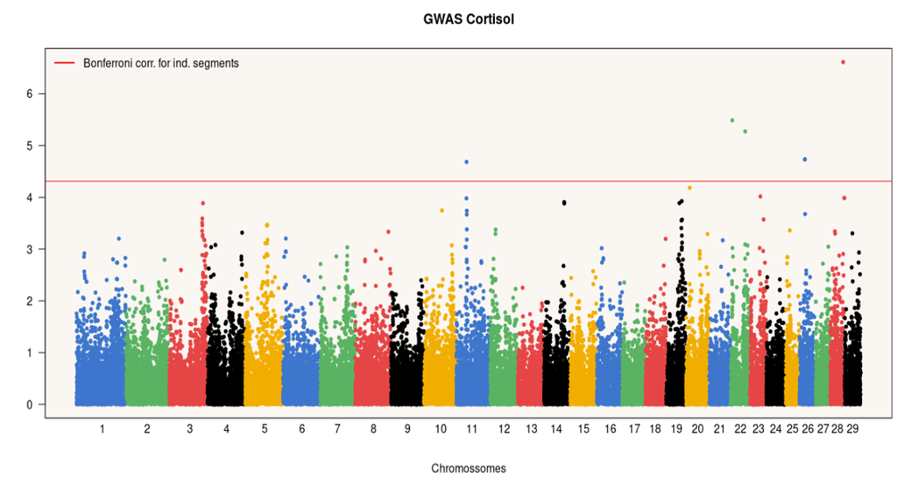

```r
Genome_Assembly_ARS_UCD_1_2 <- read_tsv("/home/bambrozi/2_CORTISOL/GWAS/sequence_report_ARS-UCD1_2.tsv")

library(dplyr)
# Filter the rows and sum the Seq length column
# Assuming your data frame is named Genome_Assembly_ARS_UCD_1_2
L <- Genome_Assembly_ARS_UCD_1_2 %>%
  filter(`UCSC style name` %in% paste0("chr", 1:29)) %>%
  summarise(total_length = sum(`Seq length`)) %>%
  pull(total_length)

# Converting bases to Morgan (1Mb = 1cM (0,01 Morgan))
L_M <- L/10^8

# The Ne measure is based on the article bellow:
Ne <- 66 #(Makanjoula et al., 2020)

NeL <- Ne*L_M

# This is the number of independent segment in the genome.
Me <- (2*NeL)/log10(NeL)


gwas<- read.table(file = "/home/bambrozi/2_CORTISOL/GWAS/GWAS_result.loco.mlma",
                  head=T, stringsAsFactors = F)

gwas$Chr<- as.factor(gwas$Chr)
gwas$logP<- -log10(gwas$p)
rmv<- which(gwas$logP == "NaN")
if (length(rmv) >=1) {gwas <- gwas[-rmv,]}

bonf<- -log10(0.05/Me)

library(GHap)
ghap.manhattan(data=gwas,chr="Chr", bp="bp", y="logP", type="p", pch = 20,
               cex=1, lwd=1, ylab="", xlab="Chromossomes",
               main="GWAS Cortisol", backcolor="#F5EFE780", chr.ang=0,)
abline(h=(bonf), col="red2")
legend("topleft", col="red2", lwd=2, c("Bonferroni corr. for ind. segments"), bty="n")


library(tidyverse)

SNP_sig_bonf_ind_seg <- filter(gwas, logP > bonf)
write.table(SNP_sig_bonf_ind_seg, file = "/home/bambrozi/2_CORTISOL/GWAS/SNP_sig_Bonf_ind_seg.txt",
            quote = FALSE, sep = "\t", row.names = FALSE, col.names = T)
```

Below we can find the list of significant SNPs after the correction for Multiple Testing

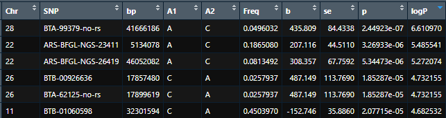

# qqPlot

I performed the qqPlot analysis using the code below:

```r
gwas<- read.table("GWAS_result.loco.mlma", h=T)
ps<- gwas$p
inflation <- function(ps) {
  chisq <- qchisq(1 - ps, 1)
  lambda <- median(chisq) / qchisq(0.5, 1)
  lambda
}
# Calculating the lambda -  the lambda statistic should be close to 1 if
#the points fall within the expected range, or greater than one if
# the observed p-values are more significant than expected.
inflation(ps)

bonf<- -log10(0.05/nrow(gwas))

gwas$log<- -log10(gwas$p)

gg_qqplot <- function(ps, ci = 0.95) {
  n  <- length(ps)
  df <- data.frame(
    observed = -log10(sort(ps)),
    expected = -log10(ppoints(n)),
    clower   = -log10(qbeta(p = (1 - ci) / 2, shape1 = 1:n, shape2 = n:1)),
    cupper   = -log10(qbeta(p = (1 + ci) / 2, shape1 = 1:n, shape2 = n:1))
  )
  log10Pe <- expression(paste("Expected -log"[10], plain(P)))
  log10Po <- expression(paste("Observed -log"[10], plain(P)))
  ggplot(df) +
    geom_ribbon(
      mapping = aes(x = expected, ymin = clower, ymax = cupper),
      alpha = 0.1
    ) +
    geom_point(aes(expected, observed), shape = 1, size = 3) +
    geom_abline(intercept = 0, slope = 1, alpha = 0.5) +
    # geom_line(aes(expected, cupper), linetype = 2, size = 0.5) +
    # geom_line(aes(expected, clower), linetype = 2, size = 0.5) +
    xlab(log10Pe) +
    ylab(log10Po)
}

## plot -----
gg_qqplot(ps) +
  theme_bw(base_size = 24) +
  annotate(
    geom = "text",
    x = -Inf,
    y = Inf,
    hjust = -0.15,
    vjust = 1 + 0.15 * 3,
    label = sprintf("λ = %.2f", inflation(ps)),
    size = 8
  ) +
  theme(
    axis.ticks = element_line(size = 0.5),
    panel.grid = element_blank()
    # panel.grid = element_line(size = 0.5, color = "grey80")
  )
```

The outcome is the qqplot below, and the lambda value is **$\lambda$ = 1.03**

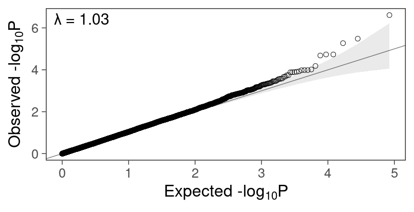

# GALLO

```r
# GALLO

#import a QTL annotation file
qtl_UCD1_2 <- import_gff_gtf(db_file="/home/bambrozi/2_CORTISOL/GALLO/Animal_QTLdb_release53_cattleARS_UCD1.gff.gz",file_type="gff")

#import a gene annotation file
gene_UDC1_2 <- import_gff_gtf(db_file="/home/bambrozi/2_CORTISOL/GALLO/Bos_taurus.ARS-UCD1.2.110.gtf.gz",file_type="gtf")

#import MARKER files = the GWAS output
gwas <- read.table(file = "/home/bambrozi/2_CORTISOL/GWAS/SNP_sig_Bonf_ind_seg.txt",
                   head=T, stringsAsFactors = F)

# Assuming "gwas" is your dataframe
gwas <- subset(gwas, select = c(Chr, SNP, bp))


colnames(gwas) <- c("CHR","SNP", "BP")


#FINDING GENES AND QTLs ARROUND THE MARKER

#FINDING GENES
out.genes <- find_genes_qtls_around_markers(db_file= gene_UDC1_2,
                                            marker_file= gwas,
                                            method = "gene",
                                            marker = "snp",
                                            interval = 50000,
                                            nThreads = NULL)

write.table(out.genes, file = "/home/bambrozi/2_CORTISOL/GALLO/out_genes_50k.txt",
            quote = FALSE, sep = "\t", row.names = FALSE, col.names = T)

write.csv(out.genes, file = "/home/bambrozi/2_CORTISOL/GALLO/out_genes_50k.csv")

#FINDING QTLs

out.qtl <- find_genes_qtls_around_markers(db_file= qtl_UCD1_2,
                                          marker_file= gwas,
                                          method = "qtl",
                                          marker = "snp",
                                          interval = 50000,
                                          nThreads = NULL)


write.table(out.qtl, file = "/home/bambrozi/2_CORTISOL/GALLO/out_qtl_50k.txt",
            quote = FALSE, sep = "\t", row.names = FALSE, col.names = T)

library(tidyverse)
out.qtl.clean <- select(out.qtl, c("CHR", "SNP", "BP", "QTL_type", "start_pos", "end_pos","QTL_ID"))
write.csv(out.qtl.clean, file = "/home/bambrozi/2_CORTISOL/GALLO/out_qtl_50k_clean.csv")
```

Dowloading the .gtf file from Ensembl https://useast.ensembl.org/info/data/ftp/index.html

Downloading the .gff file from AnimalQTLdb https://www.animalgenome.org/cgi-bin/QTLdb/index

The GALLO output are bellow:

**For GENES**

| CHR | SNP | BP | chr | start_pos | end_pos | width | strand | gene_id | gene_name | gene_biotype |
| --- | --- | --- | --- | --- | --- | --- | --- | --- | --- | --- |
| 11 | BTB-01060598 | 32301594 | 11 | 32278324 | 32766620 | 488297 | - | ENSBTAG00000046199 | NRXN1 | protein_coding |
| 11 | BTB-01060598 | 32301594 | 11 | 32280416 | 32280512 | 97 | - | ENSBTAG00000044573 | U6 | snRNA |
| 22 | ARS-BFGL-NGS-26419 | 46052082 | 22 | 45924535 | 46818511 | 893977 | - | ENSBTAG00000013117 | CACNA2D3 | protein_coding |
| 22 | ARS-BFGL-NGS-26419 | 46052082 | 22 | 46051998 | 46062657 | 10660 | + | ENSBTAG00000013124 | LRTM1 | protein_coding |
| 22 | ARS-BFGL-NGS-23411 | 5134078 | 22 | 5091037 | 5184321 | 93285 | + | ENSBTAG00000019832 | TGFBR2 | protein_coding |
| 26 | BTB-00926636 | 17857480 | 26 | 17703169 | 17846407 | 143239 | - | ENSBTAG00000011743 | TLL2 | protein_coding |
| 26 | BTB-00926636 | 17857480 | 26 | 17851539 | 17912665 | 61127 | - | ENSBTAG00000016298 | TM9SF3 | protein_coding |
| 26 | BTA-62125-no-rs | 17899619 | 26 | 17851539 | 17912665 | 61127 | - | ENSBTAG00000016298 | TM9SF3 | protein_coding |
| 26 | BTA-62125-no-rs | 17899619 | 26 | 17925643 | 18029878 | 104236 | - | ENSBTAG00000019872 | PIK3AP1 | protein_coding |
| 28 | BTA-99379-no-rs | 41666186 | 28 | 41609015 | 41649016 | 40002 | - | ENSBTAG00000007540 | GLUD1 | protein_coding |
| 28 | BTA-99379-no-rs | 41666186 | 28 | 41650333 | 41763371 | 113039 | + | ENSBTAG00000019194 | SHLD2 | protein_coding |

**FOR QTLs**

| X | CHR | SNP | BP | QTL_type | start_pos | end_pos | QTL_ID |
| --- | --- | --- | --- | --- | --- | --- | --- |
| 1 | 22 | ARS-BFGL-NGS-23411 | 5134078 | Meat_and_Carcass | 5109498 | 5109502 | 151609 |
| 2 | 22 | ARS-BFGL-NGS-23411 | 5134078 | Meat_and_Carcass | 5134076 | 5134080 | 151620 |
| 3 | 22 | ARS-BFGL-NGS-23411 | 5134078 | Meat_and_Carcass | 5173197 | 5173201 | 151601 |
| 4 | 22 | ARS-BFGL-NGS-26419 | 46052082 | Reproduction | 46052080 | 46052084 | 51802 |
| 5 | 22 | ARS-BFGL-NGS-26419 | 46052082 | Reproduction | 46052080 | 46052084 | 51803 |
| 6 | 22 | ARS-BFGL-NGS-26419 | 46052082 | Reproduction | 46052080 | 46052084 | 51804 |
| 7 | 22 | ARS-BFGL-NGS-26419 | 46052082 | Exterior | 46052080 | 46052084 | 51805 |
| 8 | 22 | ARS-BFGL-NGS-26419 | 46052082 | Production | 46052080 | 46052084 | 51806 |
| 9 | 22 | ARS-BFGL-NGS-26419 | 46052082 | Production | 46052080 | 46052084 | 51807 |
| 10 | 22 | ARS-BFGL-NGS-26419 | 46052082 | Exterior | 46052080 | 46052084 | 51808 |
| 11 | 22 | ARS-BFGL-NGS-26419 | 46052082 | Reproduction | 46052080 | 46052084 | 51809 |
| 12 | 22 | ARS-BFGL-NGS-26419 | 46052082 | Health | 46052080 | 46052084 | 51810 |
| 13 | 22 | ARS-BFGL-NGS-26419 | 46052082 | Reproduction | 46052080 | 46052084 | 51811 |
| 14 | 22 | ARS-BFGL-NGS-26419 | 46052082 | Exterior | 46052080 | 46052084 | 51812 |
| 15 | 22 | ARS-BFGL-NGS-26419 | 46052082 | Exterior | 46052080 | 46052084 | 51813 |
| 16 | 22 | ARS-BFGL-NGS-26419 | 46052082 | Milk | 46073517 | 46073521 | 243365 |
| 17 | 26 | BTB-00926636 | 17857480 | Milk | 17809768 | 17809772 | 195264 |
| 18 | 26 | BTB-00926636 | 17857480 | Milk | 17809768 | 17809772 | 200269 |
| 19 | 26 | BTB-00926636 | 17857480 | Milk | 17809768 | 17809772 | 200270 |
| 20 | 26 | BTB-00926636 | 17857480 | Milk | 17809768 | 17809772 | 205295 |
| 21 | 26 | BTB-00926636 | 17857480 | Milk | 17810363 | 17810367 | 198859 |
| 22 | 26 | BTB-00926636 | 17857480 | Milk | 17810363 | 17810367 | 203868 |
| 23 | 26 | BTB-00926636 | 17857480 | Milk | 17810363 | 17810367 | 203869 |
| 24 | 26 | BTB-00926636 | 17857480 | Milk | 17810363 | 17810367 | 210297 |
| 25 | 26 | BTB-00926636 | 17857480 | Milk | 17811021 | 17811025 | 198858 |
| 26 | 26 | BTB-00926636 | 17857480 | Milk | 17811021 | 17811025 | 203866 |
| 27 | 26 | BTB-00926636 | 17857480 | Milk | 17811021 | 17811025 | 203867 |
| 28 | 26 | BTB-00926636 | 17857480 | Milk | 17811021 | 17811025 | 210296 |
| 29 | 26 | BTB-00926636 | 17857480 | Milk | 17811725 | 17811729 | 197493 |
| 30 | 26 | BTB-00926636 | 17857480 | Milk | 17811725 | 17811729 | 202704 |

[output cut: 112 more lines]

## QTL annotation on GALLO

**QTL type**

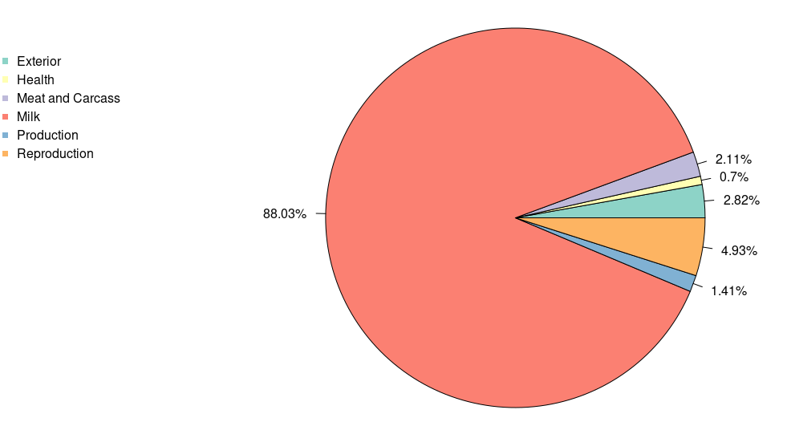

```r
#GALLO
par(mar=c(8,20,8,8))
plot_qtl_info(out.qtl, qtl_plot = "qtl_type", cex=1)
```

```r
#GALLO
par(mar=c(10,20,10,10))
plot_qtl_info(out.qtl, qtl_plot = "qtl_name", qtl_class="Reproduction")

par(mar=c(10,20,10,10))
plot_qtl_info(out.qtl, qtl_plot = "qtl_name", qtl_class="Health")
```

**Reproduction**

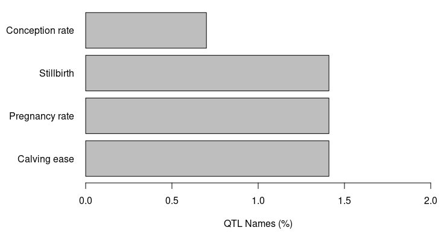

**Health**

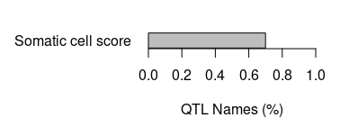

## QTL enrichment on GALLO

```r
#GALLO
#QTL enrichment analysis
out.enrich_qtl <-qtl_enrich(qtl_db= qtl_UCD1_2,
                       qtl_file= out.qtl, qtl_type = "Name",
                       enrich_type = "chromosome", chr.subset = NULL,
                       padj = "fdr",nThreads = 2)

write.csv(out.enrich_qtl,"/home/bambrozi/2_CORTISOL/GALLO/out_enrich_qtl.csv")
```

Bellow we can realize that any QTL remain after the enrichment analysis.

| X | QTL | CHR | N_QTLs | N_QTLs_db | Total_annotated_QTLs | Total_QTLs_db | pvalue | adj.pval | QTL_type |
| --- | --- | --- | --- | --- | --- | --- | --- | --- | --- |
| 1 | Calving ease | 22 | 2 | 36 | 16 | 1420 | 0.0600206 | 0.1714874 | Reproduction |
| 2 | Foot angle | 22 | 1 | 13 | 16 | 1420 | 0.1375172 | 0.2291953 | Exterior |
| 3 | Length of productive life | 22 | 1 | 24 | 16 | 1420 | 0.2398181 | 0.2997726 | Production |
| 4 | Milk yield | 22 | 1 | 31 | 16 | 1420 | 0.2988721 | 0.3516142 | Milk |
| 5 | Muscle carnosine content | 22 | 3 | 34 | 16 | 1420 | 0.0056794 | 0.1135884 | Meat and Carcass |
| 6 | Net merit | 22 | 1 | 18 | 16 | 1420 | 0.1855207 | 0.2854165 | Production |
| 7 | Pregnancy rate | 22 | 1 | 24 | 16 | 1420 | 0.2398181 | 0.2997726 | Reproduction |
| 8 | Pregnancy rate | 28 | 1 | 13 | 2 | 931 | 0.0277468 | 0.1714874 | Reproduction |
| 9 | Rear leg placement - side view | 22 | 1 | 8 | 16 | 1420 | 0.0868709 | 0.1930465 | Exterior |
| 10 | Somatic cell score | 22 | 1 | 22 | 16 | 1420 | 0.2221078 | 0.2997726 | Health |
| 11 | Stillbirth | 22 | 2 | 23 | 16 | 1420 | 0.0262437 | 0.1714874 | Reproduction |
| 12 | Teat length | 22 | 1 | 9 | 16 | 1420 | 0.0972180 | 0.1944360 | Exterior |
| 13 | Udder depth | 22 | 1 | 13 | 16 | 1420 | 0.1375172 | 0.2291953 | Exterior |
| 14 | Milk C14 index | 26 | 35 | 4086 | 90 | 13453 | 0.0519183 | 0.1714874 | Milk |
| 15 | Milk C16 index | 26 | 12 | 1557 | 90 | 13453 | 0.3466189 | 0.3851321 | Milk |
| 16 | Milk capric acid content | 26 | 1 | 283 | 90 | 13453 | 0.8533756 | 0.8533756 | Milk |
| 17 | Milk myristic acid content | 26 | 1 | 159 | 90 | 13453 | 0.6582295 | 0.6928731 | Milk |
| 18 | Milk myristoleic acid content | 26 | 26 | 2960 | 90 | 13453 | 0.0759638 | 0.1899095 | Milk |
| 19 | Milk palmitoleic acid content | 26 | 15 | 1446 | 90 | 13453 | 0.0559996 | 0.1714874 | Milk |
| 20 | Conception rate | 28 | 1 | 22 | 2 | 931 | 0.0467274 | 0.1714874 | Reproduction |

# GPROFILER

online version: https://biit.cs.ut.ee/gprofiler/gost

I got a script from Julia Rodrigues about the R package GPROFILER to perform an enrichment of my Genes.

```r
### enriquecimento genico
#install.packages("gprofiler2")
library(gprofiler2)

#Para conferir a lista de organism -> https://biit.cs.ut.ee/gprofiler/page/organism-list

#Obs: eu entro com os ids ENSOAR...
query <- read.table ("/home/bambrozi/2_CORTISOL/GALLO/out_genes_50k.txt", header = T)
query <- query[,c("gene_id")]

gene_enrich <- gost(
  query,
  organism = "btaurus",
  ordered_query = FALSE,
  multi_query = FALSE,
  significant = TRUE,
  exclude_iea = FALSE,
  measure_underrepresentation = FALSE,
  evcodes = TRUE,
  user_threshold = 0.10,
  correction_method = c("fdr"),
  domain_scope = c("annotated"),
  numeric_ns = "",
  sources = NULL,
  as_short_link = FALSE,
  highlight = FALSE
)


#str(gene_enrich) # para ver o formato dos meus dados

#selecionando apenas as informações da lista que me interessam para fazer meu data.frame
result_enrich <- data.frame(gene_enrich$result)
result_enrich <- data.frame(Category = result_enrich$source,
                            ID = result_enrich$term_id,
                            Term = result_enrich$term_name,
                            adj_pvalue = result_enrich$p_value,
                            id_ensembl = result_enrich$intersection)

write.table(result_enrich,"/home/bambrozi/2_CORTISOL/GPROFILER/gene_enrich.txt", col.names=TRUE, row.names=FALSE, sep="\t", quote=F)



gostplot(
  gene_enrich,
  capped = TRUE,
  interactive = T,
  pal = c(`GO:MF` = "#dc3912", `GO:BP` = "#ff9900", `GO:CC` = "#109618", KEGG =
            "#dd4477", REAC = "#3366cc", WP = "#0099c6", TF = "#5574a6", MIRNA = "#22aa99", HPA =
            "#6633cc", CORUM = "#66aa00", HP = "#990099")
)

#to use this function to save, it is necesssary choose interactive =F in the previous step
#to use this function create a object "publish_gostplot" in the previous step.
publish_gostplot(
  gostplot_obj,
  highlight_terms = NULL,
  filename = NULL,
  width = NA,
  height = NA
)

#CREATE A TABLE

publish_gosttable(
  gene_enrich,
  highlight_terms = NULL,
  use_colors = TRUE,
  show_columns = c("source", "term_name", "term_size", "intersection_size"),
  filename = "result_table.pdf",
  ggplot = TRUE
)

#creating a GO list to use in CATEGORIZER.
library(tidyverse)
sig_enrich <- filter(result_enrich, adj_pvalue < 0.05)
write.table(sig_enrich, file = "/home/bambrozi/2_CORTISOL/GPROFILER/gene_enrich_sig.txt", row.names = FALSE, quote = F, col.names = FALSE)
write.csv(sig_enrich, file = "/home/bambrozi/2_CORTISOL/GPROFILER/gene_enrich_sig.csv")
```

Below we can se the significant terms of this enrichment (output):

| X | Category | ID | Term | adj_pvalue | id_ensembl |
| --- | --- | --- | --- | --- | --- |
| 1 | GO:BP | GO:2001032 | regulation of double-strand break repair via nonhomologous end joining | 0.0440145 | ENSBTAG00000019194 |
| 2 | GO:BP | GO:0045910 | negative regulation of DNA recombination | 0.0440145 | ENSBTAG00000019194 |
| 3 | GO:BP | GO:0045830 | positive regulation of isotype switching | 0.0440145 | ENSBTAG00000019194 |
| 4 | GO:BP | GO:0002889 | regulation of immunoglobulin mediated immune response | 0.0440145 | ENSBTAG00000019194 |
| 5 | GO:BP | GO:0002891 | positive regulation of immunoglobulin mediated immune response | 0.0440145 | ENSBTAG00000019194 |
| 6 | GO:BP | GO:0045738 | negative regulation of DNA repair | 0.0440145 | ENSBTAG00000019194 |
| 7 | GO:BP | GO:0045191 | regulation of isotype switching | 0.0440145 | ENSBTAG00000019194 |
| 8 | GO:BP | GO:0006303 | double-strand break repair via nonhomologous end joining | 0.0440145 | ENSBTAG00000019194 |
| 9 | GO:BP | GO:0045190 | isotype switching | 0.0440145 | ENSBTAG00000019194 |
| 10 | GO:BP | GO:0043649 | dicarboxylic acid catabolic process | 0.0440145 | ENSBTAG00000007540 |
| 11 | GO:BP | GO:0006536 | glutamate metabolic process | 0.0440145 | ENSBTAG00000007540 |
| 12 | GO:BP | GO:0006538 | glutamate catabolic process | 0.0440145 | ENSBTAG00000007540 |
| 13 | GO:BP | GO:0006541 | glutamine metabolic process | 0.0440145 | ENSBTAG00000007540 |
| 14 | GO:BP | GO:0043648 | dicarboxylic acid metabolic process | 0.0440145 | ENSBTAG00000007540 |
| 15 | GO:BP | GO:0009064 | glutamine family amino acid metabolic process | 0.0440145 | ENSBTAG00000007540 |
| 16 | GO:BP | GO:0009065 | glutamine family amino acid catabolic process | 0.0440145 | ENSBTAG00000007540 |
| 17 | GO:BP | GO:0032024 | positive regulation of insulin secretion | 0.0440145 | ENSBTAG00000007540 |
| 18 | GO:BP | GO:0002208 | somatic diversification of immunoglobulins involved in immune response | 0.0440145 | ENSBTAG00000019194 |
| 19 | GO:BP | GO:2000781 | positive regulation of double-strand break repair | 0.0440145 | ENSBTAG00000019194 |
| 20 | GO:BP | GO:0016447 | somatic recombination of immunoglobulin gene segments | 0.0440145 | ENSBTAG00000019194 |
| 21 | GO:BP | GO:0045911 | positive regulation of DNA recombination | 0.0440145 | ENSBTAG00000019194 |
| 22 | GO:BP | GO:0016445 | somatic diversification of immunoglobulins | 0.0440145 | ENSBTAG00000019194 |
| 23 | GO:BP | GO:0016444 | somatic cell DNA recombination | 0.0440145 | ENSBTAG00000019194 |
| 24 | GO:BP | GO:0002712 | regulation of B cell mediated immunity | 0.0440145 | ENSBTAG00000019194 |
| 25 | GO:BP | GO:2000780 | negative regulation of double-strand break repair | 0.0440145 | ENSBTAG00000019194 |
| 26 | GO:BP | GO:2000042 | negative regulation of double-strand break repair via homologous recombination | 0.0440145 | ENSBTAG00000019194 |
| 27 | GO:BP | GO:0002381 | immunoglobulin production involved in immunoglobulin-mediated immune response | 0.0440145 | ENSBTAG00000019194 |
| 28 | GO:BP | GO:2001034 | positive regulation of double-strand break repair via nonhomologous end joining | 0.0440145 | ENSBTAG00000019194 |
| 29 | GO:BP | GO:0002204 | somatic recombination of immunoglobulin genes involved in immune response | 0.0440145 | ENSBTAG00000019194 |
| 30 | GO:BP | GO:0170040 | proteinogenic amino acid catabolic process | 0.0440145 | ENSBTAG00000007540 |
| 31 | GO:BP | GO:0170035 | L-amino acid catabolic process | 0.0440145 | ENSBTAG00000007540 |
| 32 | GO:BP | GO:0002714 | positive regulation of B cell mediated immunity | 0.0440145 | ENSBTAG00000019194 |
| 33 | GO:BP | GO:0002637 | regulation of immunoglobulin production | 0.0440145 | ENSBTAG00000019194 |
| 34 | GO:BP | GO:0002639 | positive regulation of immunoglobulin production | 0.0440145 | ENSBTAG00000019194 |
| 35 | GO:BP | GO:0002562 | somatic diversification of immune receptors via germline recombination within a single locus | 0.0440145 | ENSBTAG00000019194 |
| 36 | GO:BP | GO:0002200 | somatic diversification of immune receptors | 0.0440145 | ENSBTAG00000019194 |
| 37 | GO:BP | GO:0072350 | tricarboxylic acid metabolic process | 0.0440145 | ENSBTAG00000007540 |
| 38 | GO:BP | GO:0010569 | regulation of double-strand break repair via homologous recombination | 0.0441931 | ENSBTAG00000019194 |
| 39 | GO:BP | GO:0050871 | positive regulation of B cell activation | 0.0450137 | ENSBTAG00000019194 |
| 40 | GO:BP | GO:0002312 | B cell activation involved in immune response | 0.0451581 | ENSBTAG00000019194 |
| 41 | GO:BP | GO:0090277 | positive regulation of peptide hormone secretion | 0.0460303 | ENSBTAG00000007540 |
| 42 | GO:BP | GO:0002793 | positive regulation of peptide secretion | 0.0460303 | ENSBTAG00000007540 |
| 43 | GO:BP | GO:1901606 | alpha-amino acid catabolic process | 0.0462456 | ENSBTAG00000007540 |
| 44 | GO:BP | GO:0002377 | immunoglobulin production | 0.0462456 | ENSBTAG00000019194 |
| 45 | GO:BP | GO:0050714 | positive regulation of protein secretion | 0.0482424 | ENSBTAG00000007540 |
| 46 | GO:BP | GO:2000779 | regulation of double-strand break repair | 0.0482424 | ENSBTAG00000019194 |
| 47 | GO:BP | GO:0046887 | positive regulation of hormone secretion | 0.0482424 | ENSBTAG00000007540 |
| 48 | GO:BP | GO:0000018 | regulation of DNA recombination | 0.0482424 | ENSBTAG00000019194 |
| 49 | GO:BP | GO:0051053 | negative regulation of DNA metabolic process | 0.0482424 | ENSBTAG00000019194 |
| 50 | GO:BP | GO:0045739 | positive regulation of DNA repair | 0.0482424 | ENSBTAG00000019194 |
| 51 | GO:BP | GO:0050864 | regulation of B cell activation | 0.0482424 | ENSBTAG00000019194 |
| 52 | GO:BP | GO:0050796 | regulation of insulin secretion | 0.0482424 | ENSBTAG00000007540 |
| 53 | GO:BP | GO:0019724 | B cell mediated immunity | 0.0482424 | ENSBTAG00000019194 |
| 54 | GO:BP | GO:0009063 | amino acid catabolic process | 0.0482424 | ENSBTAG00000007540 |
| 55 | GO:BP | GO:0002824 | positive regulation of adaptive immune response based on somatic recombination of immune receptors built from immunoglobulin superfamily domains | 0.0482424 | ENSBTAG00000019194 |
| 56 | GO:BP | GO:0002708 | positive regulation of lymphocyte mediated immunity | 0.0482424 | ENSBTAG00000019194 |
| 57 | GO:BP | GO:0002821 | positive regulation of adaptive immune response | 0.0482424 | ENSBTAG00000019194 |
| 58 | GO:BP | GO:0016064 | immunoglobulin mediated immune response | 0.0482424 | ENSBTAG00000019194 |
| 59 | GO:BP | GO:0002702 | positive regulation of production of molecular mediator of immune response | 0.0482424 | ENSBTAG00000019194 |
| 60 | GO:MF | GO:0004352 | glutamate dehydrogenase (NAD+) activity | 0.0001316 | ENSBTAG00000007540 |
| 61 | GO:MF | GO:0004353 | glutamate dehydrogenase [NAD(P)+] activity | 0.0001316 | ENSBTAG00000007540 |
| 62 | GO:MF | GO:0016639 | oxidoreductase activity, acting on the CH-NH2 group of donors, NAD or NADP as acceptor | 0.0001316 | ENSBTAG00000007540 |
| 63 | GO:MF | GO:0016638 | oxidoreductase activity, acting on the CH-NH2 group of donors | 0.0020725 | ENSBTAG00000007540 |
| 64 | KEGG | KEGG:04964 | Proximal tubule bicarbonate reclamation | 0.0066374 | ENSBTAG00000007540 |
| 65 | KEGG | KEGG:00910 | Nitrogen metabolism | 0.0066374 | ENSBTAG00000007540 |
| 66 | KEGG | KEGG:00220 | Arginine biosynthesis | 0.0066374 | ENSBTAG00000007540 |
| 67 | KEGG | KEGG:00250 | Alanine, aspartate and glutamate metabolism | 0.0087709 | ENSBTAG00000007540 |
| 68 | KEGG | KEGG:01200 | Carbon metabolism | 0.0202916 | ENSBTAG00000007540 |
| 69 | KEGG | KEGG:04217 | Necroptosis | 0.0240212 | ENSBTAG00000007540 |
| 70 | REAC | REAC:R-BTA-8964539 | Glutamate and glutamine metabolism | 0.0055427 | ENSBTAG00000007540 |
| 71 | REAC | REAC:R-BTA-2151201 | Transcriptional activation of mitochondrial biogenesis | 0.0055427 | ENSBTAG00000007540 |
| 72 | REAC | REAC:R-BTA-1592230 | Mitochondrial biogenesis | 0.0076745 | ENSBTAG00000007540 |
| 73 | REAC | REAC:R-BTA-71291 | Metabolism of amino acids and derivatives | 0.0402485 | ENSBTAG00000007540 |
| 74 | REAC | REAC:R-BTA-1852241 | Organelle biogenesis and maintenance | 0.0402485 | ENSBTAG00000007540 |
| 75 | WP | WP:WP3245 | Urea cycle and metabolism of amino groups | 0.0097938 | ENSBTAG00000007540 |

Now I’m gonna make a pie chart with the categories

[figure not shown]

```r
# Load required library
library(ggplot2)

# Assuming sig_enrich$Category contains the categories
category_counts <- table(sig_enrich$Category)

# Create a pie chart
pie_chart <- ggplot(data = NULL, aes(x = factor(1), fill = names(category_counts), y = as.numeric(category_counts))) +
  geom_bar(stat = "identity", width = 1) +
  coord_polar(theta = "y") +
  labs(title = "Distribution of Categories",
       x = NULL,
       y = NULL,
       fill = "Category") +
  theme_void() +
  theme(legend.position = "right")

# Print the pie chart
print(pie_chart)
```